# Gustavo Diaz – texmeth25

## Balancing Precision and Retention in Experimental Design

**Gustavo Diaz**  
Northwestern University  
gustavo.diaz@northwestern.edu  
gustavodiaz.org

**Erin Rossiter**  
University of Notre Dame  
erossite@nd.edu  
[erossiter.com](https://erossiter.com/)

Paper and slides: [gustavodiaz.org/talk](https://gustavodiaz.org/talk.html)

## Bias-variance tradeoff as darts

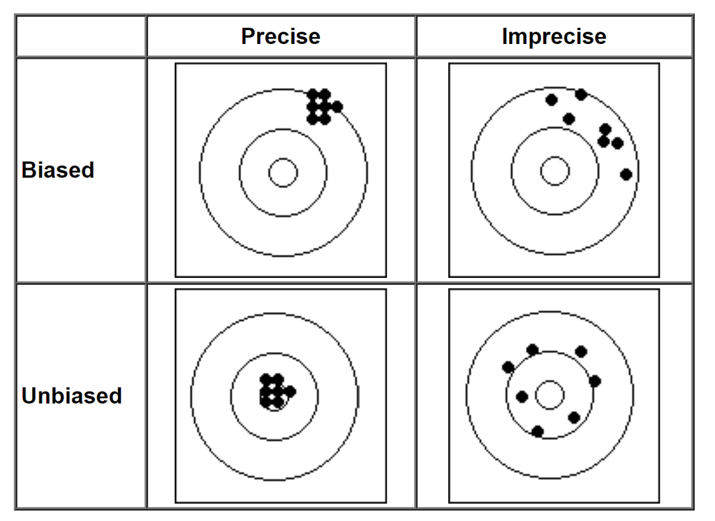

## But the game of darts is more complicated

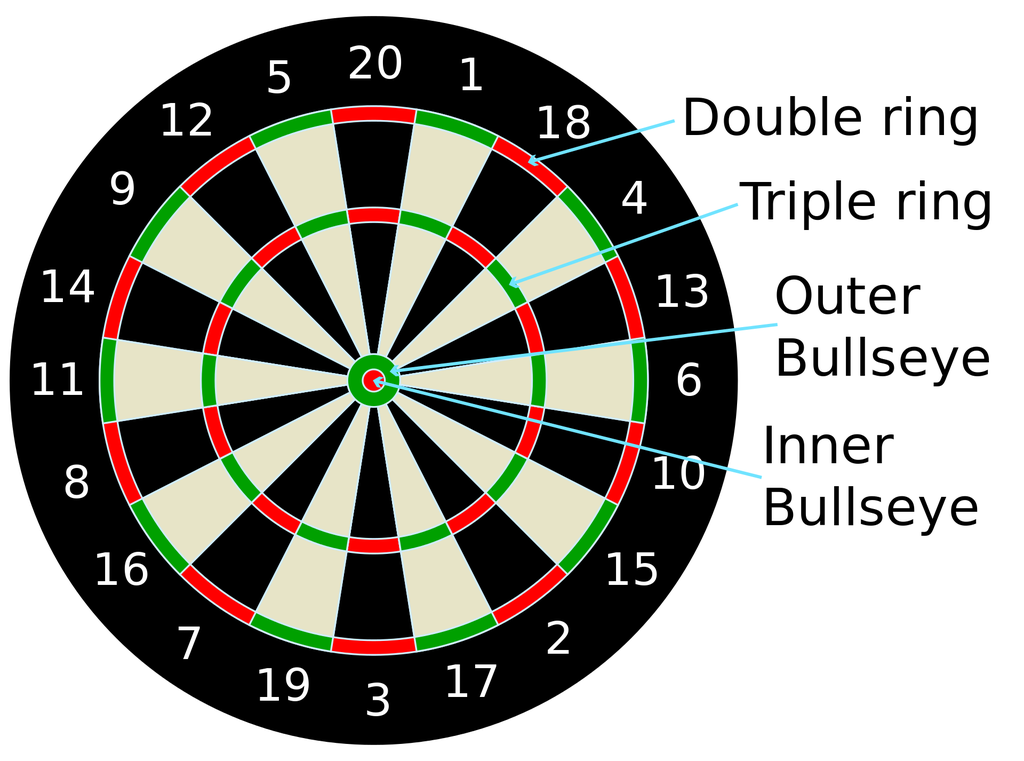

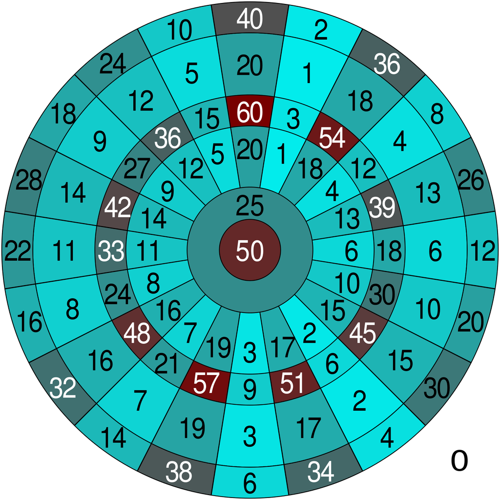

## Two types of tradeoffs

1. Improve precision at the expense of unbiasedness
2. Improving precision without sacrificing unbiasedness?

## Two types of tradeoffs

1. Improve precision at the expense of unbiasedness
2. **Improving precision without sacrificing unbiasedness?**

Cost has to come from somewhere else!

## Improving precision in experiments

Standard error of **estimated ATE** in conventional experimental design (Gerber and Green 2012, p. 57)

$$SE(\widehat{ATE}) = \sqrt{\frac{\text{Var}(Y_i(0)) + \text{Var}(Y_i(1)) + 2\text{Cov}(Y_i(0), Y_i(1))}{N-1}}$$

$N$: Sample size  
$Y_i(*)$: Potential outcomes under treatment/control (1/0)

## Improving precision in experiments

$$SE(\widehat{ATE}) = \sqrt{\frac{\text{Var}(Y_i(0)) + \text{Var}(Y_i(1)) + 2\text{Cov}(Y_i(0), Y_i(1))}{N-1}}$$

## Improving precision in experiments

$$SE(\widehat{ATE}) = \sqrt{\frac{\color{#4E2A84}{\text{Var}(Y_i(0)) + \text{Var}(Y_i(1)) + 2\text{Cov}(Y_i(0), Y_i(1))}}{N-1}}$$

**Variance component**

Decrease $SE(\widehat{ATE})$ with **alternative research designs**

## Improving precision in experiments

$$SE(\widehat{ATE}) = \sqrt{\frac{\color{#4E2A84}{\text{Var}(Y_i(0)) + \text{Var}(Y_i(1)) + 2\text{Cov}(Y_i(0), Y_i(1))}}{N-1}}$$

**Variance component**

Decrease $SE(\widehat{ATE})$ with **alternative research designs**

Block-randomization

Repeated measures

Pre-treatment covariates

Pair-matched design

Online balancing

Sequential blocking

Rerandomization

Matching

## Improving precision in experiments

$$SE(\widehat{ATE}) = \sqrt{\frac{\color{#4E2A84}{\text{Var}(Y_i(0)) + \text{Var}(Y_i(1)) + 2\text{Cov}(Y_i(0), Y_i(1))}}{N-1}}$$

**Variance component**

Decrease $SE(\widehat{ATE})$ with **alternative research designs**

**Block-randomization**

**Repeated measures**

Pre-treatment covariates

Pair-matched design

Online balancing

Sequential blocking

Rerandomization

Matching

## Improving precision in experiments

$$SE(\widehat{ATE}) = \sqrt{\frac{\color{#4E2A84}{\text{Var}(Y_i(0)) + \text{Var}(Y_i(1)) + 2\text{Cov}(Y_i(0), Y_i(1))}}{N-1}}$$

**Variance component**

Decrease $SE(\widehat{ATE})$ with **alternative research designs**

**Block-randomization**

**Repeated measures**

Pre-treatment covariates

Pair-matched design

Online balancing

Sequential blocking

Rerandomization

Matching

All require **pre-treatment information**

## Improving precision in experiments

$$SE(\widehat{ATE}) = \sqrt{\frac{\color{#4E2A84}{\text{Var}(Y_i(0)) + \text{Var}(Y_i(1)) + 2\text{Cov}(Y_i(0), Y_i(1))}}{N-1}}$$

**Variance component**

Decrease $SE(\widehat{ATE})$ with **alternative research designs**

**Block-randomization**

**Repeated measures**

Pre-treatment covariates

Pair-matched design

Online balancing

Sequential blocking

Rerandomization

Matching

All require **pre-treatment information**

Two categories:

1. Reduce variance in *observed* outcomes
2. Reduce variance in *potential* outcomes

## Improving precision in experiments

$$SE(\widehat{ATE}) = \sqrt{\frac{\color{#4E2A84}{\text{Var}(Y_i(0)) + \text{Var}(Y_i(1)) + 2\text{Cov}(Y_i(0), Y_i(1))}}{\color{#00843D}{N-1}}}$$

**Sample size component**

## Improving precision in experiments

$$SE(\widehat{ATE}) = \sqrt{\frac{\color{#4E2A84}{\text{Var}(Y_i(0)) + \text{Var}(Y_i(1)) + 2\text{Cov}(Y_i(0), Y_i(1))}}{\color{#00843D}{N-1}}}$$

**Sample size component**

Quadruple to halve $SE(\widehat{ATE})$

Precision gains from **alternative designs** may be offset by **sample loss**

## Sample loss

**Explicit**

- More pre-treatment questions $\rightarrow$ more attrition/inattention
- Block-randomization $\rightarrow$ discard units

**Implicit**

- Adding a baseline survey $\rightarrow$ half sample size
- Four more survey questions (2 min.) $\rightarrow$ 72% sample size

*Concerns about prevent widespread implementation*

## Use of alternative designs to increase precision

|  | N | % |
| --- | --- | --- |
| Pre-post | 10 | 5% |
| Blocking | 16 | 7% |
| Both | 6 | 3% |
| Neither | 184 | 85% |

Based on articles published in 2022-23 by APSR, AJPS, JOP, PB, CPS, JEPS

## Use of alternative designs to increase precision

|  | N | % |
| --- | --- | --- |
| Pre-post | 10 | 5% |
| Blocking | 16 | 7% |
| Both | 6 | 3% |
| Mention covariates | 169 | 78% |
| Nothing | 15 | 7% |

Based on articles published in 2022-23 by APSR, AJPS, JOP, PB, CPS, JEPS

## Use of alternative designs to increase precision

|  | N | % |
| --- | --- | --- |
| Pre-post | 10 | 5% |
| Blocking | 16 | 7% |
| Both | 6 | 3% |
| Mention covariates | 169 | 78% |
| Nothing | 15 | 7% |

Based on articles published in 2022-23 by APSR, AJPS, JOP, PB, CPS, JEPS

## Goal

Show that precision gains *offset* sample loss

**Paper:**

1. Replication of selected studies
2. Simulation on randomly sampled studies
3. Simulations/code/advice for pre-analysis stage

## Goal

Show that precision gains *offset* sample loss

**Paper:**

1. **Replication of selected studies**
2. Simulation on randomly sampled studies
3. Simulations/code/advice for pre-analysis stage

## Replication studies

[output not shown]

## Replication studies

[output not shown]

## Replication studies

[output not shown]

## Replication studies

[output not shown]

## Experimental conditions

| Condition | Outcomes | Randomization |
| --- | --- | --- |
| Design 1 | Post only | Complete |
| Design 2 | Pre-post | Complete |
| Design 3 | Pre-post | Blocking |

- Sample size same as original
- Increased length (DH: 43%, BG: 50%, TH: 110%)

Evaluate extent of explicit/implicit sample loss

See more here

## Explicit sample loss

[figure not shown]

## Explicit sample loss

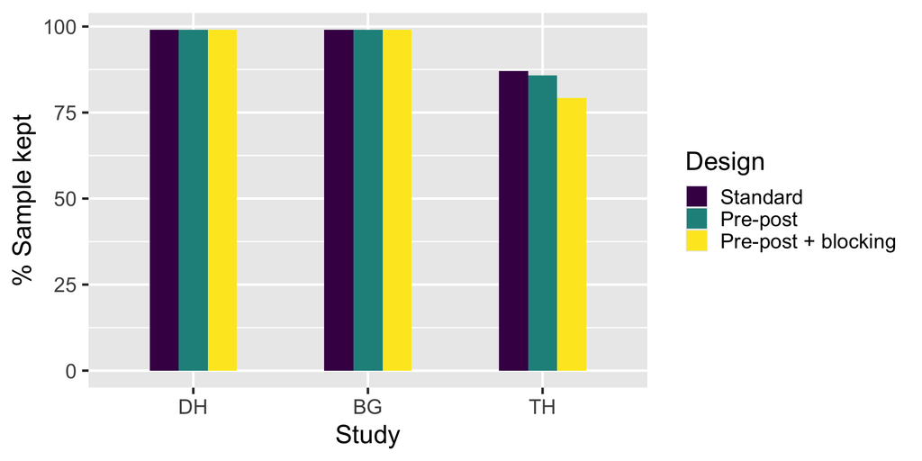

## Implicit sample loss

[figure not shown]

## Implicit sample loss

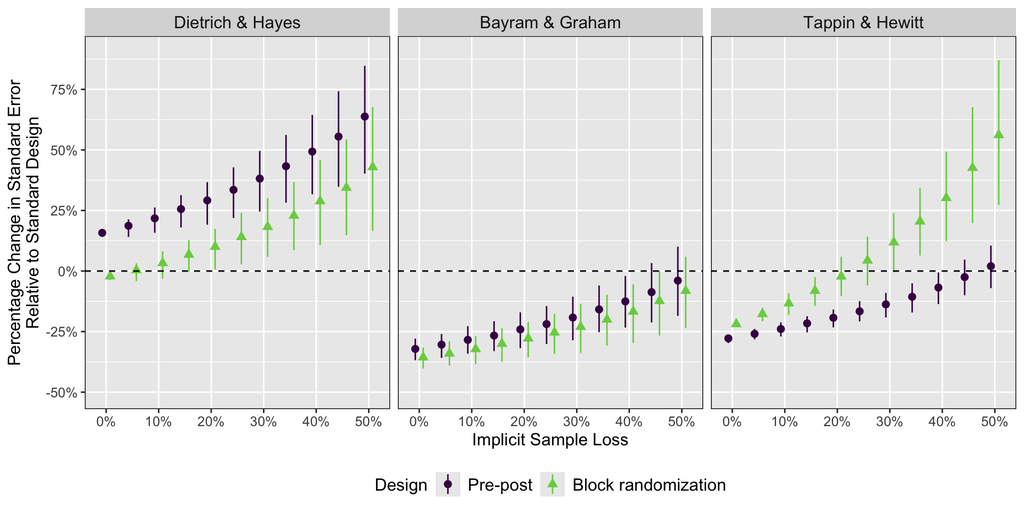

## Implicit sample loss

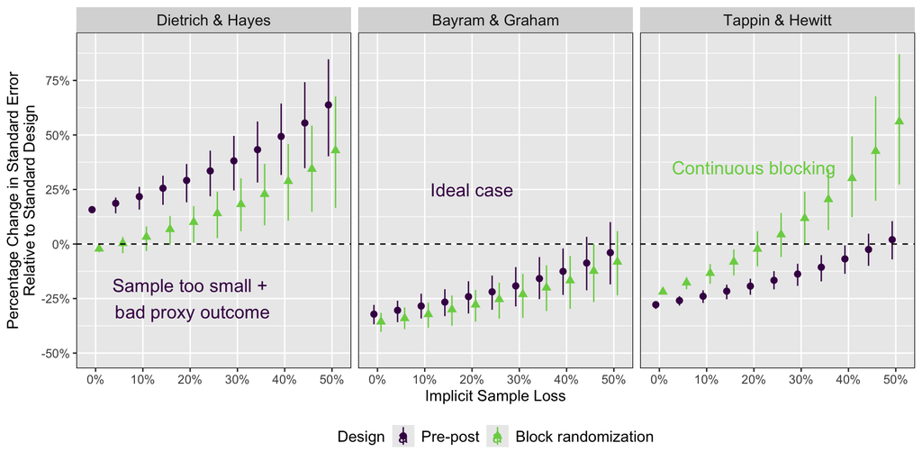

## Also in the paper

- No evidence of sample loss altering treatment effects
- No evidence of alternative designs changing *sample composition*
- Simulated replications point in the same direction
- Ideas to navigate choice at pre-analysis stage

## Summary

- **Puzzle:** Alternative designs rare
- **Argument:** Concerns about explicit/implicit sample loss offsetting precision gains
- **Findings:** Alternative designs withstand sample loss
- **Wrinkle:** Alternative designs require more attention!
- **Takeaway:** Try alternative designs!

**Paper and slides:** [gustavodiaz.org/talk](https://gustavodiaz.org/talk.html)

## Implementation details

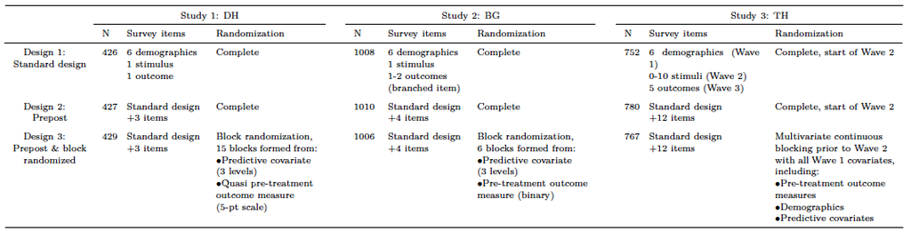

Back